# Fit the Lambda-Mean P/NBD Models

# 1 Load Datasets

We start by re-loading the data required for these models.

## 1.1 Load Pre-processed Transactional Data

```r
retail_transaction_data_tbl <- read_rds("data/retail_data_cleaned_tbl.rds")
retail_transaction_data_tbl %>% glimpse()
```

```
## Rows: 1,021,424
## Columns: 23
## $ row_id            <chr> "ROW0000001", "ROW0000002", "ROW0000003", "ROW000000…
## $ excel_sheet       <chr> "Year 2009-2010", "Year 2009-2010", "Year 2009-2010"…
## $ invoice_id        <chr> "489434", "489434", "489434", "489434", "489434", "4…
## $ stock_code        <chr> "85048", "79323P", "79323W", "22041", "21232", "2206…
## $ description       <chr> "15CM CHRISTMAS GLASS BALL 20 LIGHTS", "PINK CHERRY …
## $ quantity          <dbl> 12, 12, 12, 48, 24, 24, 24, 10, 12, 12, 24, 12, 10, …
## $ invoice_date      <date> 2009-12-01, 2009-12-01, 2009-12-01, 2009-12-01, 200…
## $ price             <dbl> 6.95, 6.75, 6.75, 2.10, 1.25, 1.65, 1.25, 5.95, 2.55…
## $ customer_id       <chr> "13085", "13085", "13085", "13085", "13085", "13085"…
## $ country           <chr> "United Kingdom", "United Kingdom", "United Kingdom"…
## $ stock_code_upr    <chr> "85048", "79323P", "79323W", "22041", "21232", "2206…
## $ cancellation      <lgl> FALSE, FALSE, FALSE, FALSE, FALSE, FALSE, FALSE, FAL…
## $ invoice_dttm      <dttm> 2009-12-01 07:45:00, 2009-12-01 07:45:00, 2009-12-0…
## $ invoice_month     <chr> "December", "December", "December", "December", "Dec…
## $ invoice_dow       <chr> "Tuesday", "Tuesday", "Tuesday", "Tuesday", "Tuesday…
## $ invoice_dom       <chr> "01", "01", "01", "01", "01", "01", "01", "01", "01"…
## $ invoice_hour      <chr> "07", "07", "07", "07", "07", "07", "07", "07", "07"…
## $ invoice_minute    <chr> "45", "45", "45", "45", "45", "45", "45", "45", "45"…
## $ invoice_woy       <chr> "49", "49", "49", "49", "49", "49", "49", "49", "49"…
## $ invoice_ym        <chr> "200912", "200912", "200912", "200912", "200912", "2…
## $ stock_value       <dbl> 83.40, 81.00, 81.00, 100.80, 30.00, 39.60, 30.00, 59…
## $ invoice_monthprop <dbl> 0.04347826, 0.04347826, 0.04347826, 0.04347826, 0.04…
## $ exclude           <lgl> FALSE, FALSE, FALSE, FALSE, FALSE, FALSE, FALSE, FAL…
```

We also want to load the customer transactional data.

```r
customer_transactions_tbl <- read_rds("data/customer_transactions_tbl.rds")
customer_transactions_tbl %>% glimpse()
```

```
## Rows: 37,031
## Columns: 4
## $ tnx_timestamp <dttm> 2009-12-01 07:45:00, 2009-12-01 07:45:59, 2009-12-01 09…
## $ customer_id   <chr> "13085", "13085", "13078", "15362", "18102", "12682", "1…
## $ invoice_id    <chr> "489434", "489435", "489436", "489437", "489438", "48943…
## $ total_spend   <dbl> 505.30, 145.80, 630.33, 310.75, 2286.24, 426.30, 50.40, …
```

Finally, we want to load the various datasets used to fit the P/NBD models

```r
btyd_fitdata_tbl <- read_rds("data/btyd_fitdata_tbl.rds")

btyd_fitdata_tbl %>% glimpse()
```

```
## Rows: 4,716
## Columns: 6
## $ customer_id    <chr> "12346", "12347", "12348", "12349", "12350", "12351", "…
## $ first_tnx_date <dttm> 2009-12-14 08:34:00, 2010-10-31 14:19:59, 2010-09-27 1…
## $ last_tnx_date  <dttm> 2011-01-18 10:00:59, 2011-01-26 14:29:59, 2011-01-25 1…
## $ x              <dbl> 11, 2, 2, 2, 0, 0, 6, 0, 0, 3, 1, 2, 7, 4, 3, 1, 1, 0, …
## $ t_x            <dbl> 57.151488095, 12.429563492, 17.117361111, 25.970535714,…
## $ T_cal          <dbl> 67.520437, 21.628968, 26.482242, 48.063492, 8.190377, 1…
```

```r
btyd_obs_stats_tbl <- read_rds("data/btyd_obs_stats_tbl.rds")

btyd_obs_stats_tbl %>% glimpse()
```

```
## Rows: 3,849
## Columns: 4
## $ customer_id <chr> "12347", "12348", "12349", "12352", "12353", "12354", "123…
## $ tnx_count   <int> 5, 2, 1, 3, 1, 1, 1, 2, 1, 2, 2, 3, 9, 2, 4, 1, 1, 2, 2, 1…
## $ first_tnx   <dttm> 2011-04-07 10:43:00, 2011-04-05 10:47:00, 2011-11-21 09:5…
## $ last_tnx    <dttm> 2011-12-07 15:51:59, 2011-09-25 13:13:00, 2011-11-21 09:5…
```

```r
extreme_customers_tbl <- read_rds("data/extreme_customers_tbl.rds")

extreme_customers_tbl %>% glimpse()
```

```
## Rows: 1,637
## Columns: 6
## $ customer_id    <chr> "12350", "12351", "12353", "12355", "12357", "12365", "…
## $ first_tnx_date <dttm> 2011-02-02 16:00:59, 2010-11-29 15:23:00, 2010-10-27 1…
## $ last_tnx_date  <dttm> 2011-02-02 16:00:59, 2010-11-29 15:23:00, 2010-10-27 1…
## $ x              <dbl> 0, 0, 0, 0, 1, 1, 0, 0, 0, 0, 0, 0, 0, 0, 0, 0, 0, 0, 0…
## $ t_x            <dbl> 0.000000000, 0.000000000, 0.000000000, 0.000000000, 0.0…
## $ T_cal          <dbl> 8.190377, 17.479861, 22.209921, 44.928671, 19.368552, 5…
```

## 1.2 Construct Customer Cohorts

Later in this worksheet we will want to create customer cohorts based on the date of the first transaction for each customer.

```r
customer_cohortdata_tbl <- customer_transactions_tbl %>%
  group_by(customer_id) %>%
  summarise(
    .groups = "drop",

    first_tnx_date = min(tnx_timestamp)
    ) %>%
  mutate(
    cohort_qtr = first_tnx_date %>% as.yearqtr(),
    cohort_ym  = first_tnx_date %>% format("%Y %m"),

    .after = "customer_id"
    )

customer_cohortdata_tbl %>% glimpse()
```

```
## Rows: 5,878
## Columns: 4
## $ customer_id    <chr> "12346", "12347", "12348", "12349", "12350", "12351", "…
## $ cohort_qtr     <yearqtr> 2009 Q4, 2010 Q4, 2010 Q3, 2010 Q2, 2011 Q1, 2010 Q…
## $ cohort_ym      <chr> "2009 12", "2010 10", "2010 09", "2010 04", "2011 02", …
## $ first_tnx_date <dttm> 2009-12-14 08:34:00, 2010-10-31 14:19:59, 2010-09-27 1…
```

# 2 Fit the Hierarchical Lambda-Mean P/NBD Model

```r
stan_modeldir <- "stan_models"
stan_codedir  <-   "stan_code"
```

```
## functions {
##   #include util_functions.stan
## }
##
## data {
##   int<lower=1> n;             // number of customers
##
##   vector<lower=0>[n] t_x;     // time to most recent purchase
##   vector<lower=0>[n] T_cal;   // total observation time
##   vector<lower=0>[n] x;       // number of purchases observed
##
##   real<lower=0> lambda_cv;    // prior cv   for lambda
##   real<lower=0> mu_mn;        // prior mean for mu
##   real<lower=0> mu_cv;        // prior cv   for mu
##
##   real          lambda_mn_p1; // hyperprior p1 for lambda mean
##   real<lower=0> lambda_mn_p2; // hyperprior p2 for lambda mean
## }
##
## transformed data {
##   real<lower=0> s    = 1 / (mu_cv * mu_cv);
##   real<lower=0> beta = 1 / (mu_cv * mu_cv * mu_mn);
## }
##
##
## parameters {
##   real<lower=0> lambda_mn;
##
##   vector<lower=0>[n] lambda; // purchase rate
##   vector<lower=0>[n] mu;     // lifetime dropout rate
## }
##
##
## transformed parameters {
##   real<lower=0> r;
##   real<lower=0> alpha;
##
##   r     = 1 / (lambda_cv * lambda_cv);
##   alpha = 1 / (lambda_cv * lambda_cv * lambda_mn);
## }
##
## model {
##   // model the hyper-prior
##   lambda_mn ~ lognormal(lambda_mn_p1, lambda_mn_p2);
##
##   // setting priors
##   lambda ~ gamma(r, alpha);
##   mu     ~ gamma(s,  beta);
##
##   target += calculate_pnbd_loglik(n, lambda, mu, x, t_x, T_cal);
## }
##
## generated quantities {
##   vector[n] p_alive;         // Probability that they are still "alive"
##
##   p_alive = 1 ./ (1 + mu ./ (mu + lambda) .* (exp((lambda + mu) .* (T_cal - t_x)) - 1));
## }
```

We now compile this model using `CmdStanR`.

```r
pnbd_hierlambdamn_stanmodel <- cmdstan_model(
  "stan_code/pnbd_hierlambdamn.stan",
  include_paths =   stan_codedir,
  pedantic      =           TRUE,
  dir           =  stan_modeldir
  )
```

## 2.1 Fit the Model

We then use this compiled model with our data to produce a fit of the data.

```r
stan_modelname <- "pnbd_hierlambdamn"
stanfit_prefix <- str_c("fit_", stan_modelname)

stan_data_lst <- btyd_fitdata_tbl %>%
  select(customer_id, x, t_x, T_cal) %>%
  compose_data(
    lambda_mn_p1 = log(1) - 0.5 * (1.0)^2,
    lambda_mn_p2 = 1,

    lambda_cv = 1.00,

    mu_mn     = 0.05,
    mu_cv     = 0.60,
    )

pnbd_hierlambdamn_stanfit <- pnbd_hierlambdamn_stanmodel$sample(
  data            =                stan_data_lst,
  chains          =                            4,
  iter_warmup     =                          500,
  iter_sampling   =                          500,
  seed            =                         4201,
  save_warmup     =                         TRUE,
  output_dir      =                stan_modeldir,
  output_basename =               stanfit_prefix,
  )
```

```
## Running MCMC with 4 parallel chains...
##
## Chain 1 Iteration:   1 / 1000 [  0%]  (Warmup)
## Chain 2 Iteration:   1 / 1000 [  0%]  (Warmup)
## Chain 3 Iteration:   1 / 1000 [  0%]  (Warmup)
## Chain 4 Iteration:   1 / 1000 [  0%]  (Warmup)
## Chain 2 Iteration: 100 / 1000 [ 10%]  (Warmup)
## Chain 3 Iteration: 100 / 1000 [ 10%]  (Warmup)
## Chain 2 Iteration: 200 / 1000 [ 20%]  (Warmup)
## Chain 1 Iteration: 100 / 1000 [ 10%]  (Warmup)
## Chain 4 Iteration: 100 / 1000 [ 10%]  (Warmup)
## Chain 2 Iteration: 300 / 1000 [ 30%]  (Warmup)
## Chain 3 Iteration: 200 / 1000 [ 20%]  (Warmup)
## Chain 4 Iteration: 200 / 1000 [ 20%]  (Warmup)
## Chain 1 Iteration: 200 / 1000 [ 20%]  (Warmup)
## Chain 2 Iteration: 400 / 1000 [ 40%]  (Warmup)
## Chain 3 Iteration: 300 / 1000 [ 30%]  (Warmup)
## Chain 4 Iteration: 300 / 1000 [ 30%]  (Warmup)
## Chain 1 Iteration: 300 / 1000 [ 30%]  (Warmup)
## Chain 2 Iteration: 500 / 1000 [ 50%]  (Warmup)
## Chain 2 Iteration: 501 / 1000 [ 50%]  (Sampling)
## Chain 3 Iteration: 400 / 1000 [ 40%]  (Warmup)
## Chain 4 Iteration: 400 / 1000 [ 40%]  (Warmup)
## Chain 1 Iteration: 400 / 1000 [ 40%]  (Warmup)
## Chain 2 Iteration: 600 / 1000 [ 60%]  (Sampling)
## Chain 3 Iteration: 500 / 1000 [ 50%]  (Warmup)
## Chain 3 Iteration: 501 / 1000 [ 50%]  (Sampling)
## Chain 4 Iteration: 500 / 1000 [ 50%]  (Warmup)
## Chain 4 Iteration: 501 / 1000 [ 50%]  (Sampling)
## Chain 2 Iteration: 700 / 1000 [ 70%]  (Sampling)
## Chain 1 Iteration: 500 / 1000 [ 50%]  (Warmup)
## Chain 1 Iteration: 501 / 1000 [ 50%]  (Sampling)
## Chain 3 Iteration: 600 / 1000 [ 60%]  (Sampling)
## Chain 4 Iteration: 600 / 1000 [ 60%]  (Sampling)
## Chain 2 Iteration: 800 / 1000 [ 80%]  (Sampling)
## Chain 1 Iteration: 600 / 1000 [ 60%]  (Sampling)
## Chain 3 Iteration: 700 / 1000 [ 70%]  (Sampling)
## Chain 4 Iteration: 700 / 1000 [ 70%]  (Sampling)
## Chain 2 Iteration: 900 / 1000 [ 90%]  (Sampling)
## Chain 1 Iteration: 700 / 1000 [ 70%]  (Sampling)
## Chain 3 Iteration: 800 / 1000 [ 80%]  (Sampling)
## Chain 4 Iteration: 800 / 1000 [ 80%]  (Sampling)
## Chain 2 Iteration: 1000 / 1000 [100%]  (Sampling)
## Chain 2 finished in 228.9 seconds.
## Chain 1 Iteration: 800 / 1000 [ 80%]  (Sampling)
## Chain 3 Iteration: 900 / 1000 [ 90%]  (Sampling)
## Chain 4 Iteration: 900 / 1000 [ 90%]  (Sampling)
## Chain 3 Iteration: 1000 / 1000 [100%]  (Sampling)
## Chain 1 Iteration: 900 / 1000 [ 90%]  (Sampling)
## Chain 3 finished in 244.4 seconds.
## Chain 4 Iteration: 1000 / 1000 [100%]  (Sampling)
## Chain 4 finished in 247.3 seconds.
## Chain 1 Iteration: 1000 / 1000 [100%]  (Sampling)
## Chain 1 finished in 253.4 seconds.
##
## All 4 chains finished successfully.
## Mean chain execution time: 243.5 seconds.
## Total execution time: 253.7 seconds.
```

```r
pnbd_hierlambdamn_stanfit$summary()
```

```
## # A tibble: 14,152 × 10
##    variable       mean   median      sd     mad       q5      q95  rhat ess_bulk
##    <chr>         <dbl>    <dbl>   <dbl>   <dbl>    <dbl>    <dbl> <dbl>    <dbl>
##  1 lp__       -1.15e+5 -1.15e+5 7.40e+1 7.26e+1 -1.15e+5 -1.14e+5  1.00     665.
##  2 lambda_mn   1.10e-1  1.10e-1 2.03e-3 2.02e-3  1.06e-1  1.13e-1  1.00    1903.
##  3 lambda[1]   1.65e-1  1.60e-1 4.98e-2 4.91e-2  9.35e-2  2.54e-1  1.00    2240.
##  4 lambda[2]   1.08e-1  9.46e-2 6.68e-2 5.84e-2  2.61e-2  2.35e-1  1.00    2341.
##  5 lambda[3]   9.06e-2  8.04e-2 5.36e-2 4.55e-2  2.33e-2  1.97e-1  1.00    2480.
##  6 lambda[4]   6.70e-2  5.92e-2 3.78e-2 3.40e-2  2.02e-2  1.41e-1  1.00    2961.
##  7 lambda[5]   6.72e-2  4.60e-2 6.90e-2 4.83e-2  3.59e-3  2.05e-1  1.00    2232.
##  8 lambda[6]   6.31e-2  4.01e-2 7.34e-2 4.31e-2  3.04e-3  2.03e-1  1.01    2348.
##  9 lambda[7]   2.40e-1  2.27e-1 9.24e-2 8.55e-2  1.13e-1  4.05e-1  1.00    2423.
## 10 lambda[8]   6.39e-2  3.90e-2 7.59e-2 4.27e-2  2.88e-3  2.09e-1  1.00    1676.
## # … with 14,142 more rows, and 1 more variable: ess_tail <dbl>
```

We have some basic HMC-based validity statistics we can check.

```r
pnbd_hierlambdamn_stanfit$cmdstan_diagnose()
```

```
## Processing csv files: /home/rstudio/workshop/stan_models/fit_pnbd_hierlambdamn-1.csvWarning: non-fatal error reading adaptation data
## , /home/rstudio/workshop/stan_models/fit_pnbd_hierlambdamn-2.csvWarning: non-fatal error reading adaptation data
## , /home/rstudio/workshop/stan_models/fit_pnbd_hierlambdamn-3.csvWarning: non-fatal error reading adaptation data
## , /home/rstudio/workshop/stan_models/fit_pnbd_hierlambdamn-4.csvWarning: non-fatal error reading adaptation data
##
##
## Checking sampler transitions treedepth.
## Treedepth satisfactory for all transitions.
##
## Checking sampler transitions for divergences.
## No divergent transitions found.
##
## Checking E-BFMI - sampler transitions HMC potential energy.
## E-BFMI satisfactory.
##
## Effective sample size satisfactory.
##
## The following parameters had split R-hat greater than 1.05:
##   lambda[716], lambda[1491], lambda[3554], mu[2830], mu[3188], mu[3670], mu[4097], p_alive[43], p_alive[51], p_alive[109], p_alive[116], p_alive[133], p_alive[145], p_alive[225], p_alive[274], p_alive[281], p_alive[333], p_alive[346], p_alive[370], p_alive[438], p_alive[458], p_alive[487], p_aliv…
## Such high values indicate incomplete mixing and biased estimation.
## You should consider regularizating your model with additional prior information or a more effective parameterization.
##
## Processing complete.
```

## 2.2 Visual Diagnostics of the Sample Validity

Now that we have a sample from the posterior distribution we need to create a few different visualisations of the diagnostics.

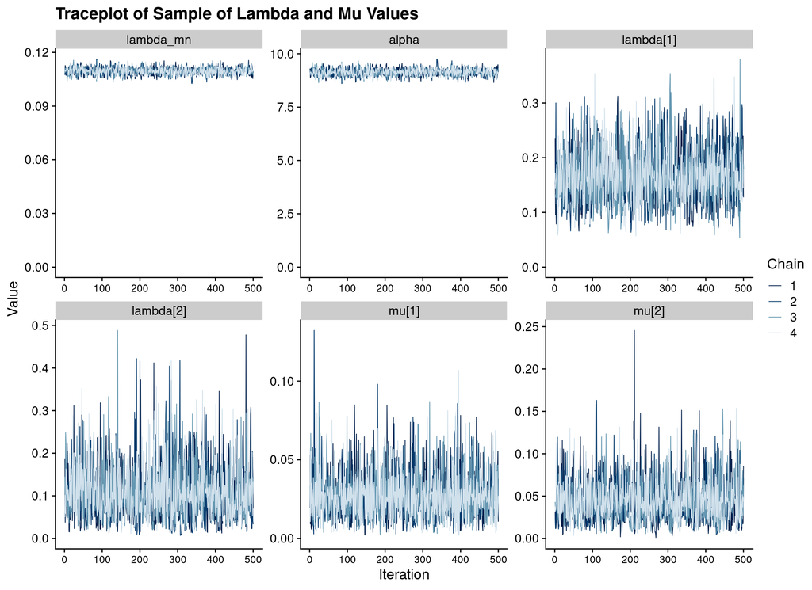

```r
pnbd_hierlambdamn_stanfit$draws(inc_warmup = FALSE) %>%
  mcmc_trace(pars = c("lambda_mn", "alpha", "lambda[1]", "lambda[2]", "mu[1]", "mu[2]")) +
  expand_limits(y = 0) +
  labs(
    x = "Iteration",
    y = "Value",
    title = "Traceplot of Sample of Lambda and Mu Values"
    ) +
  theme(axis.text.x = element_text(size = 10))
```

A common MCMC diagnostic is $\hat{R}$ - which is a measure of the ‘similarity’ of the chains.

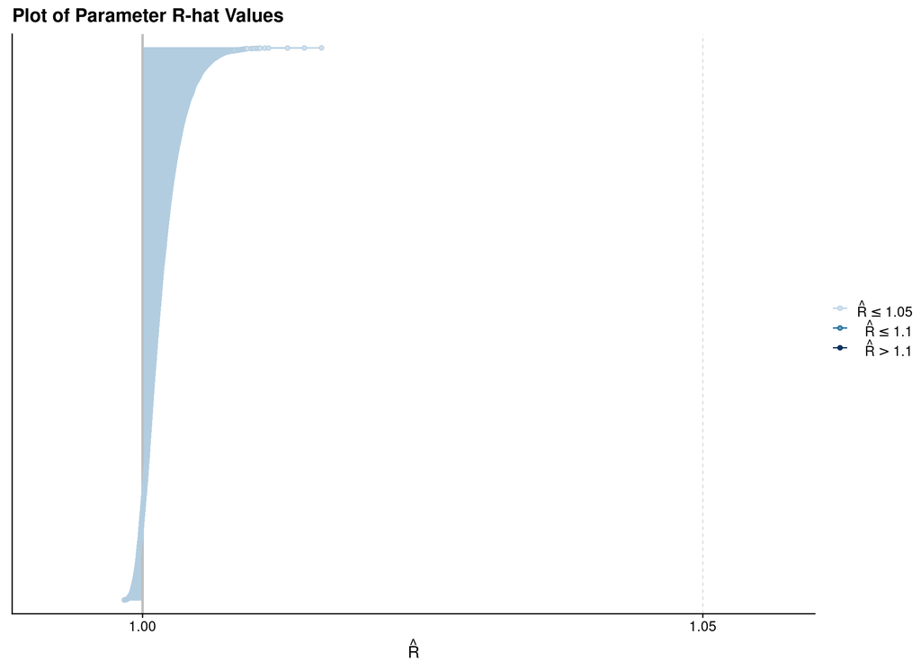

```r
pnbd_hierlambdamn_stanfit %>%
  rhat(pars = c("lambda_mn", "lambda", "mu")) %>%
  mcmc_rhat() +
    ggtitle("Plot of Parameter R-hat Values")
```

Related to this quantity is the concept of *effective sample size*, $N_{eff}$, an estimate of the size of the sample from a statistical information point of view.

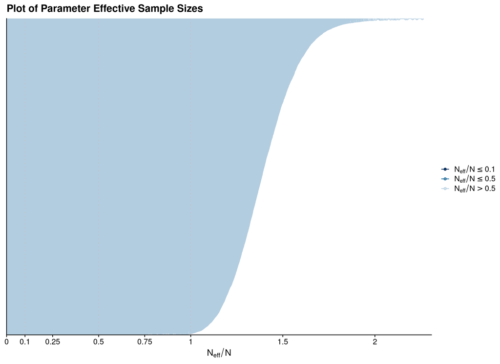

```r
pnbd_hierlambdamn_stanfit %>%
  neff_ratio(pars = c("lambda_mn", "lambda", "mu")) %>%
  mcmc_neff() +
    ggtitle("Plot of Parameter Effective Sample Sizes")
```

Finally, we also want to look at autocorrelation in the chains for each parameter.

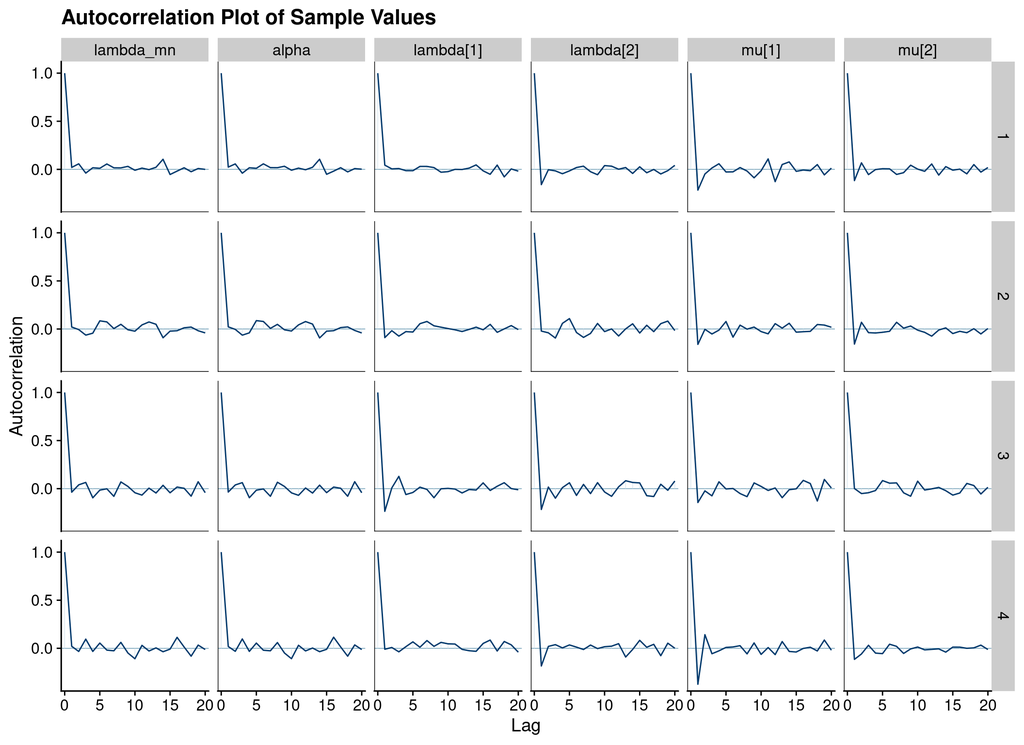

```r
pnbd_hierlambdamn_stanfit$draws() %>%
  mcmc_acf(pars = c("lambda_mn", "alpha", "lambda[1]", "lambda[2]", "mu[1]", "mu[2]")) +
    ggtitle("Autocorrelation Plot of Sample Values")
```

## 2.3 Validate the Hierarchical Lambda-Mean Model

We now want to validate the outputs of this model by looking at the posteriors for both $\lambda$, $\mu$ and `p_alive`, and then running our simulations using these outputs.

```r
pnbd_hierlambdamn_validation_tbl <- pnbd_hierlambdamn_stanfit %>%
  recover_types(btyd_fitdata_tbl) %>%
  spread_draws(lambda[customer_id], mu[customer_id], p_alive[customer_id]) %>%
  ungroup() %>%
  select(
    customer_id, draw_id = .draw, post_lambda = lambda, post_mu = mu, p_alive
    )

pnbd_hierlambdamn_validation_tbl %>% glimpse()
```

```
## Rows: 9,432,000
## Columns: 5
## $ customer_id <chr> "12346", "12346", "12346", "12346", "12346", "12346", "123…
## $ draw_id     <int> 1, 2, 3, 4, 5, 6, 7, 8, 9, 10, 11, 12, 13, 14, 15, 16, 17,…
## $ post_lambda <dbl> 0.2359220, 0.0958103, 0.1149060, 0.0787812, 0.1925450, 0.1…
## $ post_mu     <dbl> 0.05282770, 0.00921769, 0.01427110, 0.00677627, 0.00579885…
## $ p_alive     <dbl> 0.223720, 0.852502, 0.762660, 0.898381, 0.833766, 0.361753…
```

Having constructed our simulations inputs, we now generate our simulations.

```r
precompute_dir <- "precompute/pnbd_hierlambdamn"

precomputed_tbl <- dir_ls(precompute_dir) %>%
  enframe(name = NULL, value = "sim_file") %>%
  mutate(sim_file = sim_file %>% as.character())


pnbd_hierlambdamn_validsims_lookup_tbl <- pnbd_hierlambdamn_validation_tbl %>%
  group_nest(customer_id, .key = "cust_params") %>%
  mutate(
    sim_file = glue(
      "{precompute_dir}/sims_pnbd_hierlambdamn_{customer_id}.rds"
      )
    )


exec_tbl <-  pnbd_hierlambdamn_validsims_lookup_tbl %>%
  anti_join(precomputed_tbl, by = "sim_file")


if(exec_tbl %>% nrow() > 0) {
  exec_tbl %>%
    mutate(
      calc_file = future_map2_lgl(
        sim_file, cust_params,
        run_pnbd_simulations_chunk,
        start_dttm = as.POSIXct("2011-04-01"),
        end_dttm   = as.POSIXct("2011-12-10"),

        .options = furrr_options(
          globals  = c(
            "calculate_event_times", "rgamma_mucv", "gamma_mucv2shaperate",
            "generate_pnbd_validation_transactions"
            ),
          packages   = c("tidyverse", "fs"),
          scheduling = FALSE,
          seed       = 4202
          ),
        .progress = TRUE
        )
      )
}

exec_tbl %>% glimpse()
```

```
## Rows: 0
## Columns: 3
## $ customer_id <chr>
## $ cust_params <list<tibble[,4]>> list()
## $ sim_file    <glue>
```

```r
pnbd_hierlambdamn_validsims_lookup_tbl %>% glimpse()
```

```
## Rows: 4,716
## Columns: 3
## $ customer_id <chr> "12346", "12347", "12348", "12349", "12350", "12351", "123…
## $ cust_params <list<tibble[,4]>> [<tbl_df[2000 x 4]>], [<tbl_df[2000 x 4]>], […
## $ sim_file    <glue> "precompute/pnbd_hierlambdamn/sims_pnbd_hierlambdamn_1234…
```

We now load all the simulations into a file.

```r
pnbd_hierlambdamn_validsims_tbl <- pnbd_hierlambdamn_validsims_lookup_tbl %>%
  mutate(
    data = map(sim_file, ~ .x %>% read_rds() %>% select(draw_id, sim_tnx_count, sim_tnx_last))
    ) %>%
  select(customer_id, sim_file, data) %>%
  unnest(data)

pnbd_hierlambdamn_validsims_tbl %>% glimpse()
```

```
## Rows: 9,432,000
## Columns: 5
## $ customer_id   <chr> "12346", "12346", "12346", "12346", "12346", "12346", "1…
## $ sim_file      <glue> "precompute/pnbd_hierlambdamn/sims_pnbd_hierlambdamn_12…
## $ draw_id       <int> 1, 2, 3, 4, 5, 6, 7, 8, 9, 10, 11, 12, 13, 14, 15, 16, 1…
## $ sim_tnx_count <int> 0, 2, 1, 0, 3, 0, 1, 0, 0, 0, 0, 5, 0, 0, 0, 7, 0, 0, 0,…
## $ sim_tnx_last  <dttm> NA, 2011-04-14 04:54:35, 2011-06-14 10:55:09, NA, 2011-…
```

We also want to look at how our simulated data compares to the transaction data that occurred after Apr 1 2011.

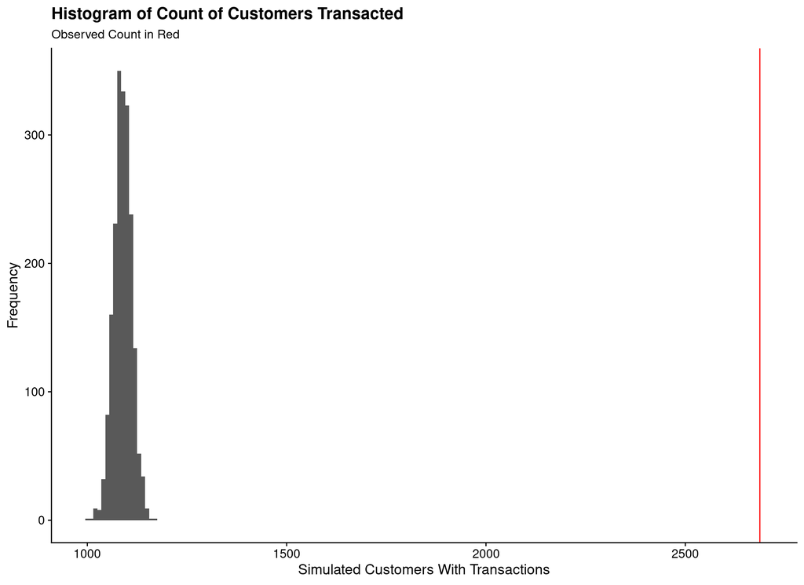

```r
tnx_data_tbl <- btyd_obs_stats_tbl %>%
  semi_join(pnbd_hierlambdamn_validsims_tbl, by = "customer_id")

obs_customer_count  <- tnx_data_tbl %>% nrow()
obs_total_tnx_count <- tnx_data_tbl %>% pull(tnx_count) %>% sum()

pnbd_hierlambdamn_tnx_simsumm_tbl <- pnbd_hierlambdamn_validsims_tbl %>%
  group_by(draw_id) %>%
  summarise(
    .groups = "drop",

    sim_customer_count  = length(sim_tnx_count[sim_tnx_count > 0]),
    sim_total_tnx_count = sum(sim_tnx_count)
    )


ggplot(pnbd_hierlambdamn_tnx_simsumm_tbl) +
  geom_histogram(aes(x = sim_customer_count), binwidth = 10) +
  geom_vline(aes(xintercept = obs_customer_count), colour = "red") +
  labs(
    x = "Simulated Customers With Transactions",
    y = "Frequency",
    title = "Histogram of Count of Customers Transacted",
    subtitle = "Observed Count in Red"
    )
```

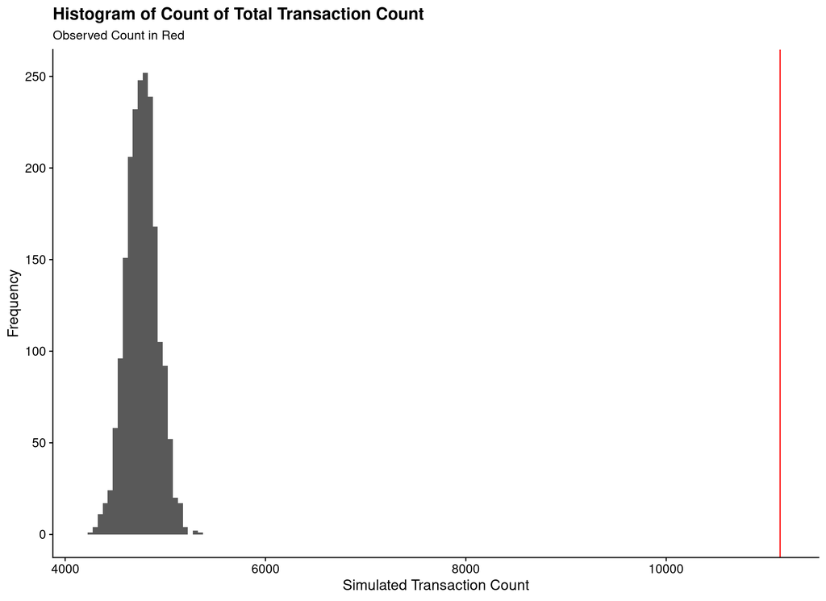

```r
ggplot(pnbd_hierlambdamn_tnx_simsumm_tbl) +
  geom_histogram(aes(x = sim_total_tnx_count), binwidth = 50) +
  geom_vline(aes(xintercept = obs_total_tnx_count), colour = "red") +
  labs(
    x = "Simulated Transaction Count",
    y = "Frequency",
    title = "Histogram of Count of Total Transaction Count",
    subtitle = "Observed Count in Red"
    )
```

So this is pretty terrible. We now have a worse model than the one with fixed priors!

We are not giving up though, and can try to segment our customers into cohorts, splitting them by initial transaction time. We then give each of these cohorts their own prior for lambda.

# 3 Fit Hierarchical Cohort-Lambda Model

To add the cohort information to our model we need to add this information into our fit data in Stan.

```r
btyd_cohort_fitdata_tbl <- btyd_fitdata_tbl %>%
  select(-first_tnx_date, -last_tnx_date) %>%
  inner_join(customer_cohortdata_tbl, by = "customer_id") %>%
  mutate(
    cohort = cohort_qtr %>% as.character()
    ) %>%
  select(customer_id, cohort, x, t_x, T_cal)

btyd_cohort_fitdata_tbl %>% glimpse()
```

```
## Rows: 4,716
## Columns: 5
## $ customer_id <chr> "12346", "12347", "12348", "12349", "12350", "12351", "123…
## $ cohort      <chr> "2009 Q4", "2010 Q4", "2010 Q3", "2010 Q2", "2011 Q1", "20…
## $ x           <dbl> 11, 2, 2, 2, 0, 0, 6, 0, 0, 3, 1, 2, 7, 4, 3, 1, 1, 0, 0, …
## $ t_x         <dbl> 57.151488095, 12.429563492, 17.117361111, 25.970535714, 0.…
## $ T_cal       <dbl> 67.520437, 21.628968, 26.482242, 48.063492, 8.190377, 17.4…
```

We now want to modify our Stan model to allow each customer cohort to have its own hyperprior.

```
## functions {
##   #include util_functions.stan
## }
##
## data {
##   int<lower=1> n;             // number of customers
##   int<lower=1> n_cohort;
##
##   array[n] int<lower=1,upper=n_cohort> cohort;
##
##   vector<lower=0>[n] t_x;     // time to most recent purchase
##   vector<lower=0>[n] T_cal;   // total observation time
##   vector<lower=0>[n] x;       // number of purchases observed
##
##   real<lower=0> lambda_cv;    // prior cv   for lambda
##   real<lower=0> mu_mn;        // prior mean for mu
##   real<lower=0> mu_cv;        // prior cv   for mu
##
##   real          lambda_mn_p1; // hyperprior p1 for lambda mean
##   real<lower=0> lambda_mn_p2; // hyperprior p2 for lambda mean
## }
##
## transformed data {
##   real<lower=0> s    = 1 / (mu_cv * mu_cv);
##   real<lower=0> beta = 1 / (mu_cv * mu_cv * mu_mn);
## }
##
##
## parameters {
##   vector<lower=0>[n_cohort] lambda_mn;
##
##   vector<lower=0>[n] lambda; // purchase rate
##   vector<lower=0>[n] mu;     // lifetime dropout rate
## }
##
##
## transformed parameters {
##   real<lower=0>             r;
##   vector<lower=0>[n_cohort] alpha;
##
##   r     = 1  / (lambda_cv  * lambda_cv);
##   alpha = 1 ./ (lambda_cv .* lambda_cv .* lambda_mn);
## }
##
## model {
##   // model the hyper-prior
##   lambda_mn ~ lognormal(lambda_mn_p1, lambda_mn_p2);
##
##   // setting priors
##   lambda ~ gamma(r, alpha[cohort]);
##   mu     ~ gamma(s,          beta);
##
##   target += calculate_pnbd_loglik(n, lambda, mu, x, t_x, T_cal);
## }
##
## generated quantities {
##   vector[n] mpl;             // intermediate value for efficiency
##   vector[n] p_alive;         // Probability that they are still "alive"
##
##   mpl     = mu + lambda;
##   p_alive = 1 ./ (1 + mu ./ mpl .* (exp(mpl .* (T_cal - t_x)) - 1));
## }
```

We now compile this model using `CmdStanR`.

```r
pnbd_hiercohortlambda_stanmodel <- cmdstan_model(
  "stan_code/pnbd_hiercohortlambda.stan",
  include_paths =   stan_codedir,
  pedantic      =           TRUE,
  dir           =  stan_modeldir
  )
```

## 3.1 Fit the Model

We then use this compiled model with our data to produce a fit of the data.

```r
stan_modelname <- "pnbd_hiercohortlambda"
stanfit_prefix <- str_c("fit_", stan_modelname)

stan_data_lst <- btyd_cohort_fitdata_tbl %>%
  select(customer_id, cohort, x, t_x, T_cal) %>%
  compose_data(
    lambda_mn_p1 = log(1) - 0.5 * (1.0)^2,
    lambda_mn_p2 = 1,

    lambda_cv = 1.00,

    mu_mn     = 0.05,
    mu_cv     = 0.60,
    )

pnbd_hiercohortlambda_stanfit <- pnbd_hiercohortlambda_stanmodel$sample(
  data            =                stan_data_lst,
  chains          =                            4,
  iter_warmup     =                          500,
  iter_sampling   =                          500,
  seed            =                         4201,
  save_warmup     =                         TRUE,
  output_dir      =                stan_modeldir,
  output_basename =               stanfit_prefix,
  )
```

```
## Running MCMC with 4 chains, at most 8 in parallel...
##
## Chain 1 Iteration:   1 / 1000 [  0%]  (Warmup)
## Chain 2 Iteration:   1 / 1000 [  0%]  (Warmup)
## Chain 3 Iteration:   1 / 1000 [  0%]  (Warmup)
## Chain 4 Iteration:   1 / 1000 [  0%]  (Warmup)
## Chain 3 Iteration: 100 / 1000 [ 10%]  (Warmup)
## Chain 4 Iteration: 100 / 1000 [ 10%]  (Warmup)
## Chain 2 Iteration: 100 / 1000 [ 10%]  (Warmup)
## Chain 1 Iteration: 100 / 1000 [ 10%]  (Warmup)
## Chain 3 Iteration: 200 / 1000 [ 20%]  (Warmup)
## Chain 4 Iteration: 200 / 1000 [ 20%]  (Warmup)
## Chain 1 Iteration: 200 / 1000 [ 20%]  (Warmup)
## Chain 2 Iteration: 200 / 1000 [ 20%]  (Warmup)
## Chain 3 Iteration: 300 / 1000 [ 30%]  (Warmup)
## Chain 4 Iteration: 300 / 1000 [ 30%]  (Warmup)
## Chain 1 Iteration: 300 / 1000 [ 30%]  (Warmup)
## Chain 2 Iteration: 300 / 1000 [ 30%]  (Warmup)
## Chain 3 Iteration: 400 / 1000 [ 40%]  (Warmup)
## Chain 4 Iteration: 400 / 1000 [ 40%]  (Warmup)
## Chain 1 Iteration: 400 / 1000 [ 40%]  (Warmup)
## Chain 2 Iteration: 400 / 1000 [ 40%]  (Warmup)
## Chain 3 Iteration: 500 / 1000 [ 50%]  (Warmup)
## Chain 3 Iteration: 501 / 1000 [ 50%]  (Sampling)
## Chain 4 Iteration: 500 / 1000 [ 50%]  (Warmup)
## Chain 4 Iteration: 501 / 1000 [ 50%]  (Sampling)
## Chain 1 Iteration: 500 / 1000 [ 50%]  (Warmup)
## Chain 1 Iteration: 501 / 1000 [ 50%]  (Sampling)
## Chain 2 Iteration: 500 / 1000 [ 50%]  (Warmup)
## Chain 3 Iteration: 600 / 1000 [ 60%]  (Sampling)
## Chain 2 Iteration: 501 / 1000 [ 50%]  (Sampling)
## Chain 4 Iteration: 600 / 1000 [ 60%]  (Sampling)
## Chain 1 Iteration: 600 / 1000 [ 60%]  (Sampling)
## Chain 3 Iteration: 700 / 1000 [ 70%]  (Sampling)
## Chain 2 Iteration: 600 / 1000 [ 60%]  (Sampling)
## Chain 4 Iteration: 700 / 1000 [ 70%]  (Sampling)
## Chain 1 Iteration: 700 / 1000 [ 70%]  (Sampling)
## Chain 2 Iteration: 700 / 1000 [ 70%]  (Sampling)
## Chain 3 Iteration: 800 / 1000 [ 80%]  (Sampling)
## Chain 4 Iteration: 800 / 1000 [ 80%]  (Sampling)
## Chain 1 Iteration: 800 / 1000 [ 80%]  (Sampling)
## Chain 2 Iteration: 800 / 1000 [ 80%]  (Sampling)
## Chain 3 Iteration: 900 / 1000 [ 90%]  (Sampling)
## Chain 4 Iteration: 900 / 1000 [ 90%]  (Sampling)
## Chain 1 Iteration: 900 / 1000 [ 90%]  (Sampling)
## Chain 2 Iteration: 900 / 1000 [ 90%]  (Sampling)
## Chain 3 Iteration: 1000 / 1000 [100%]  (Sampling)
## Chain 3 finished in 135.8 seconds.
## Chain 4 Iteration: 1000 / 1000 [100%]  (Sampling)
## Chain 4 finished in 138.2 seconds.
## Chain 1 Iteration: 1000 / 1000 [100%]  (Sampling)
## Chain 1 finished in 140.4 seconds.
## Chain 2 Iteration: 1000 / 1000 [100%]  (Sampling)
## Chain 2 finished in 144.0 seconds.
##
## All 4 chains finished successfully.
## Mean chain execution time: 139.6 seconds.
## Total execution time: 144.5 seconds.
```

```r
pnbd_hiercohortlambda_stanfit$summary()
```

```
## # A tibble: 18,878 × 10
##    variable       mean   median      sd     mad       q5      q95  rhat ess_bulk
##    <chr>         <dbl>    <dbl>   <dbl>   <dbl>    <dbl>    <dbl> <dbl>    <dbl>
##  1 lp__       -1.14e+5 -1.14e+5 7.28e+1 7.34e+1 -1.15e+5 -1.14e+5  1.01     695.
##  2 lambda_mn…  1.76e-1  1.75e-1 6.23e-3 6.25e-3  1.66e-1  1.86e-1  1.00    2729.
##  3 lambda_mn…  9.54e-2  9.53e-2 3.27e-3 3.40e-3  9.01e-2  1.01e-1  1.00    2009.
##  4 lambda_mn…  7.52e-2  7.52e-2 3.53e-3 3.57e-3  6.97e-2  8.10e-2  1.00    1700.
##  5 lambda_mn…  1.01e-1  1.01e-1 5.69e-3 5.80e-3  9.18e-2  1.10e-1  1.00    1428.
##  6 lambda_mn…  7.09e-2  7.09e-2 4.29e-3 4.47e-3  6.39e-2  7.79e-2  1.00     885.
##  7 lambda_mn…  7.05e-2  7.02e-2 8.21e-3 8.54e-3  5.77e-2  8.47e-2  1.01     559.
##  8 lambda[1]   1.71e-1  1.65e-1 5.06e-2 4.85e-2  1.00e-1  2.63e-1  1.00    3747.
##  9 lambda[2]   9.18e-2  8.14e-2 5.30e-2 4.91e-2  2.53e-2  1.92e-1  1.00    2034.
## 10 lambda[3]   8.90e-2  7.86e-2 5.12e-2 4.70e-2  2.58e-2  1.83e-1  1.00    3988.
## # … with 18,868 more rows, and 1 more variable: ess_tail <dbl>
```

We have some basic HMC-based validity statistics we can check.

```r
pnbd_hiercohortlambda_stanfit$cmdstan_diagnose()
```

```
## Processing csv files: /home/rstudio/workshop/stan_models/fit_pnbd_hiercohortlambda-1.csvWarning: non-fatal error reading adaptation data
## , /home/rstudio/workshop/stan_models/fit_pnbd_hiercohortlambda-2.csvWarning: non-fatal error reading adaptation data
## , /home/rstudio/workshop/stan_models/fit_pnbd_hiercohortlambda-3.csvWarning: non-fatal error reading adaptation data
## , /home/rstudio/workshop/stan_models/fit_pnbd_hiercohortlambda-4.csvWarning: non-fatal error reading adaptation data
##
##
## Checking sampler transitions treedepth.
## Treedepth satisfactory for all transitions.
##
## Checking sampler transitions for divergences.
## No divergent transitions found.
##
## Checking E-BFMI - sampler transitions HMC potential energy.
## E-BFMI satisfactory.
##
## Effective sample size satisfactory.
##
## Split R-hat values satisfactory all parameters.
##
## Processing complete, no problems detected.
```

## 3.2 Visual Diagnostics of the Sample Validity

Now that we have a sample from the posterior distribution we need to create a few different visualisations of the diagnostics.

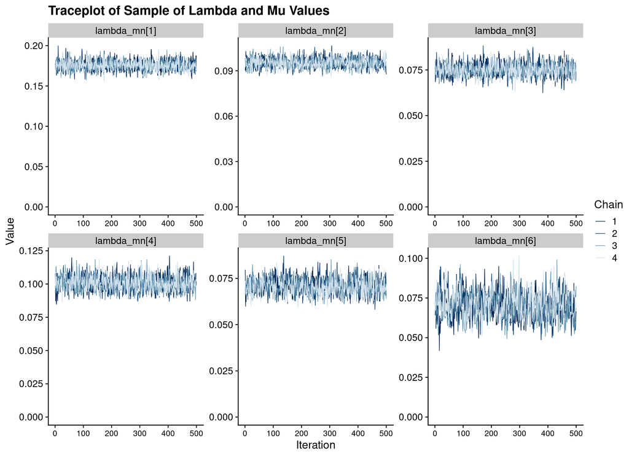

```r
pnbd_hiercohortlambda_stanfit$draws(inc_warmup = FALSE) %>%
  mcmc_trace(
    pars = c(
      "lambda_mn[1]", "lambda_mn[2]", "lambda_mn[3]",
      "lambda_mn[4]", "lambda_mn[5]", "lambda_mn[6]"
      )
    ) +
  expand_limits(y = 0) +
  labs(
    x = "Iteration",
    y = "Value",
    title = "Traceplot of Sample of Lambda and Mu Values"
    ) +
  theme(axis.text.x = element_text(size = 10))
```

A common MCMC diagnostic is $\hat{R}$ - which is a measure of the ‘similarity’ of the chains.

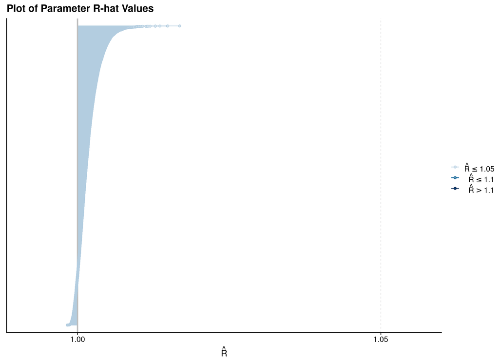

```r
pnbd_hiercohortlambda_stanfit %>%
  rhat(pars = c("lambda_mn", "lambda", "mu")) %>%
  mcmc_rhat() +
    ggtitle("Plot of Parameter R-hat Values")
```

Related to this quantity is the concept of *effective sample size*, $N_{eff}$, an estimate of the size of the sample from a statistical information point of view.

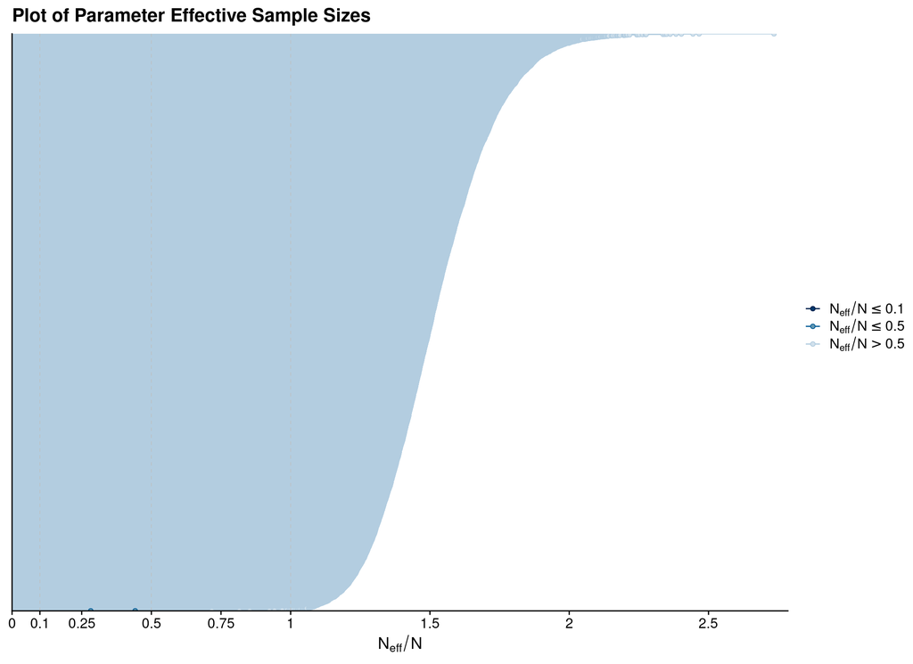

```r
pnbd_hiercohortlambda_stanfit %>%
  neff_ratio(pars = c("lambda_mn", "lambda", "mu")) %>%
  mcmc_neff() +
    ggtitle("Plot of Parameter Effective Sample Sizes")
```